# Analysis VCS Taxol Experiments 1/2

# OVERVIWEW

## Experiment

Here, we analyze the data from two experiments of RPE-1 cells treated with DMSO or taxol for 30h and then activated according to their nuclear shape phenotype over 12 hours. In experiment 1, cells were sorted according to their activation state i.e. nuclear shape phenotype. In experiment 2, cells with normal and lobulated nuclear shapes were sorted into the same tube, for the purposes of batch correction.

## Analysis strategy

# LOAD PACKAGES

```r
library(devtools)
library(Matrix)
library(spdep)
library(SummarizedExperiment)
library(SingleCellExperiment)
load_all('../../../bin/monocle3/')
```

```
Loading monocle3
```

```r
library(monocle3)
#BiocManager::install('BiocSingular')
load_all('../../../bin/batchelor/')
```

```
Loading batchelor
```

```r
library(batchelor)
library(Seurat)
library(monocle)
library(scran)
library(scRNAseq)
library(SingleCellExperiment)
library(scater)
library(ggpubr)
library(AUC)
library(piano)
library(slam)
library(MASS)
library(dplyr)
source('GSA_hyper_helper_functions.R')
source('loadGSCSafe.R')
source('seurat_functions.R')
set.seed(9)
```

# FUNCTIONS

## Seurat cell cycle analysis

Arguments: matrix file location; feature data; phenotypic data Output: phenotypic dataframe + cell cycle scores, cell cycle designations

Based on https://satijalab.org/seurat/v3.0/cell_cycle_vignette.html

```r
seurat_cellcycle <- function(mat_file, pd, fd){
  # Read in the expression matrix The first row is a header row, the first column is rownames
  exp.mat <- readMM(file = mat_file)
  row.names(exp.mat) = fd$gene_short_name
  colnames(exp.mat) = pd$cell
  # A list of cell cycle markers, from Tirosh et al, 2015, is loaded with Seurat.  We can
  # segregate this list into markers of G2/M phase and markers of S phase
  s.genes <- cc.genes$s.genes
  g2m.genes <- cc.genes$g2m.genes
  # Create our Seurat object and complete the initalization steps
  marrow <- CreateSeuratObject(counts = exp.mat)
  marrow <- NormalizeData(marrow)
  marrow <- FindVariableFeatures(marrow, selection.method = "vst")
  marrow <- ScaleData(marrow, features = rownames(marrow))
  marrow <- RunPCA(marrow, features = VariableFeatures(marrow), ndims.print = 6:10, nfeatures.print = 10)
  marrow <- CellCycleScoring(marrow, s.features = s.genes, g2m.features = g2m.genes, set.ident = TRUE)
  # merg seurat cell cycle object with the phenodata frame
  orig_order    <- pd$cell # save the original order of cells
  pd            <- merge(pd, marrow[[]][,c('S.Score', 'G2M.Score', 'Phase')], by.x = 'cell', by.y = 'row.names') # add cell cycle info
  pd$sample     <- sapply(pd$cell, function(x) unlist(strsplit(as.character(x), '-'))[[2]])
  row.names(pd) <- pd$cell
  pd            <- pd[match(orig_order, row.names(pd)),]
  return(pd)
  }
```

## preprocess cds

Inputs: matrix file location; feature data; phenotypic data Output: cds with seurat cell cycle annotations, processed with reduced_dimensions to plot UMAP

```r
preprocess_seurat <- function(mat_file, pd, fd, annotate_seurat = TRUE){
  # add_seurat
  if(annotate_seurat) {
    print('Annotating with Seurat cell cycle analysis..')
    pd <- seurat_cellcycle(mat_file, pd, fd)}
  # load rep1 data
  print('Creating cds..')
  cds <- new_cell_data_set(readMM(mat_file),
                                cell_metadata = pd,
                                gene_metadata = fd)
  # preprocess
  print('Preprocessing cds..')
  cds  <- preprocess_cds(cds, num_dim = 100)
  # remove outlier cells
  print('Removing outlier cells..')
  low_size_factor_val <- mean(colData(cds)$Size_Factor) - (2*sd(colData(cds)$Size_Factor))
  hi_size_factor_val <- mean(colData(cds)$Size_Factor) + (2*sd(colData(cds)$Size_Factor))
  cds <- cds[,which(cds$Size_Factor > low_size_factor_val & cds$Size_Factor < hi_size_factor_val )]
  # remove genes detected < 10 times
  gene_total_umis <- rowSums(exprs(cds))
  to_keep         <- names(gene_total_umis)[which(gene_total_umis > 9)]
  cds             <- cds[to_keep,]
  # plot
  print('Preparing UMAP..')
  cds = reduce_dimension(cds, reduction_method = 'UMAP', umap.n_neighbors = 30)
  return(cds)}
```

# 1. PREPROCESS DATA AND USE SEURAT TO GENERATE CELL CYCLE SCORES

## Experiment 1

sample 3 = taxol, normal-appearing (200ms) sample 4 = taxol, lobulated (800ms)

```r
# prep phenodata
pd1            <- data.frame(cell = read.csv('../data/cellranger_outputGEO/barcodes_exp1.tsv', sep = '\t', header = F),
                 stringsAsFactors = F)
colnames(pd1)  <- 'cell'
# prep featuredata
fd1            <- as.data.frame(read.csv('../data/cellranger_outputGEO/features_exp1.tsv', sep = '\t', header = F),
                    stringsAsFactors = F)[,c(1,2)]
colnames(fd1)  <- c('id', 'gene_short_name')
row.names(fd1) <- fd1$id
# reannotate phenodata with Seurat
cds_exp1      <- preprocess_seurat(mat_file = '../data/cellranger_outputGEO/matrix_exp1.mtx',
                                  pd = pd1,
                                  fd = fd1)
```

```
[1] "Annotating with Seurat cell cycle analysis.."
```

```
Non-unique features (rownames) present in the input matrix, making uniqueFeature names cannot have underscores ('_'), replacing with dashes ('-')Performing log-normalization
```

```
PC_ 6
Positive:  AXL, HNRNPH1, B4GALT1, CTTN, TSPYL1, PPP1CB, SDC4, CBX6, CTNNB1, CAPZA1
Negative:  FTH1, FTL, ZFAS1, EIF4EBP1, SCG5, BEX2, NQO1, PIF1, BRI3, RPS18
PC_ 7
Positive:  AXL, HNRNPH1, B4GALT1, CTTN, TSPYL1, CBX6, PPP1CB, CTNNB1, CAPZA1, C1orf56
Negative:  DDIT3, PMAIP1, GADD45A, CDKN1A, MDM2, ACTA2, BTG2, IL8, DDIT4, TXNIP
PC_ 8
Positive:  AXL, FTH1, HNRNPH1, PPP1CB, CTTN, FTL, TSPYL1, B4GALT1, CBX6, CHP1
Negative:  CTGF, CYR61, TUBA1A, STC2, TM4SF1, PLAT, CTSC, DKK1, ANKRD1, CCND1
PC_ 9
Positive:  DYNLL1, BEX1, FTH1, CALM2, NGFRAP1, FTL, PHLDA2, PHLDA1, H3F3B, CMTM7
Negative:  MALAT1, HSP90AB1, UBC, ANKRD1, AXL, HJURP, CTSC, PIF1, FST, FAM83D
PC_ 10
Positive:  CCND1, FTH1, TXNRD1, PTX3, SQSTM1, SNHG8, CALM2, NUPR1, SNHG7, BRI3
Negative:  HIST1H4C, HMGB1, HMGN2, KIAA0101, STMN1, TNFRSF12A, TUBA1B, H2AFZ, HIST1H1E, PLAU
[1] "Creating cds.."
[1] "Preprocessing cds.."
[1] "Removing outlier cells.."
[1] "Preparing UMAP.."
```

```r
# retrieve median UMIs per cell
median(colSums(exprs(cds_exp1)))
```

```
[1] 9073
```

```
No trajectory to plot. Has learn_graph() been called yet?
```

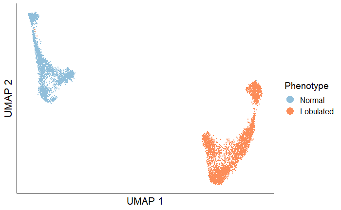

```r
# annotate cells with phenotype
colData(cds_exp1)$pheno = factor('Normal', levels = c('Normal', 'Lobulated', 'Mixed'))
colData(cds_exp1)[which(colData(cds_exp1)$sample == 4 ),'pheno'] = as.factor('Lobulated')
# plot
plot_cells(cds_exp1, color_cells_by = 'pheno', label_cell_groups = F) + scale_color_manual(values = c('#91bfdb', '#fc8d59')) +
  theme_classic() +
  theme(axis.text=element_text(size=14),
        axis.title=element_text(size=16),
        strip.text.x = element_text(size=16),
        strip.background = element_blank(),
        axis.text.y=element_blank(),
        axis.ticks.y=element_blank(),
        axis.text.x=element_blank(),
        axis.ticks.x=element_blank(),
        legend.title = element_text(size = 14),
        legend.text = element_text(size = 12)) +
  guides(color=guide_legend(title='Phenotype', override.aes = list(size=5))) # note potential batch effect in taxol treated cells
```

### check cell cycle distributions

```r
cell_cycle_counts = table(colData(cds_exp1)[which(colData(cds_exp1)$sample %in% c(3,4)),c('pheno','Phase')])
totals = apply(cell_cycle_counts, 1, sum)
cell_cycle_counts = as.data.frame(t(cell_cycle_counts))
cell_cycle_counts$perc = apply(cell_cycle_counts, 1, function(x) as.numeric(x['Freq']) / totals[x['pheno']])
cell_cycle_counts$pheno = factor(cell_cycle_counts$pheno, levels = c('Normal', 'Lobulated'))
print(cell_cycle_counts)
```

| Phase | pheno | Freq | perc |
| --- | --- | --- | --- |
| G1 | Normal | 1133 | 0.4366089 |
| G2M | Normal | 715 | 0.2755299 |
| S | Normal | 747 | 0.2878613 |
| G1 | Lobulated | 1954 | 0.5288227 |
| G2M | Lobulated | 984 | 0.2663058 |
| S | Lobulated | 757 | 0.2048714 |
| G1 | NA | 0 | NaN |
| G2M | NA | 0 | NaN |
| S | NA | 0 | NaN |

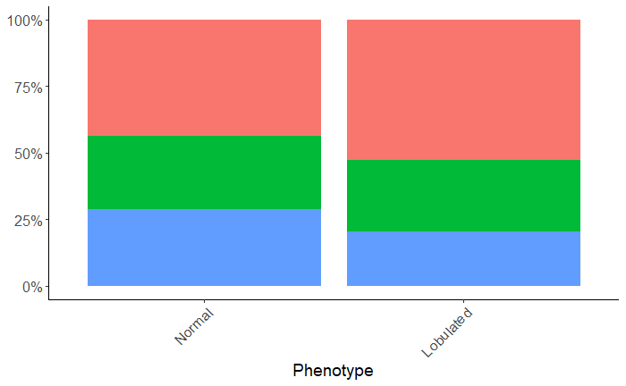

```r
# plot cell cycle distribution
ggplot(cell_cycle_counts[which(cell_cycle_counts$pheno %in% c('Normal', 'Lobulated')),], aes(x = pheno, y = perc, fill = Phase)) + geom_bar(stat = 'identity') +
  theme_classic() +
  theme(axis.text=element_text(size=12),
        axis.text.x = element_text(angle = 45, hjust=1),
        axis.title=element_text(size=14),
        legend.position  = 'none') +
  scale_y_continuous(labels = scales::percent_format(accuracy = 1)) +
        xlab('Phenotype') +
        ylab(NULL)
```

## Experiment 2

```r
# prep phenodata
pd2            <- data.frame(cell = read.csv('../data/cellranger_outputGEO/barcodes_exp2.tsv', sep = '\t', header = F),
                 stringsAsFactors = F)
colnames(pd2)  <- 'cell'
# prep featuredata
fd2            <- as.data.frame(read.csv('../data/cellranger_outputGEO/features_exp2.tsv', sep = '\t', header = F),
                    stringsAsFactors = F)
colnames(fd2)  <- c('id', 'gene_short_name')
row.names(fd2) <- fd2$id
# annotate phenodata with Seurat
cds_exp2      <- preprocess_seurat(mat_file = '../data/cellranger_outputGEO/matrix_exp2.mtx',
                                  pd = pd2,
                                  fd = fd2)
```

```
[1] "Annotating with Seurat cell cycle analysis.."
```

```
Non-unique features (rownames) present in the input matrix, making uniquePerforming log-normalization
```

```
PC_ 6
Positive:  HMGA1, GLRX, HSPE1, LSM4, ARHGAP11B, CDK4, LSM3, H3F3B, MXD3, MT1X
Negative:  B4GALT1, CTNNB1, C1orf56, AXL, HNRNPH1, PPP1CB, SAR1A, CBX6, PHKG1, CTTN
PC_ 7
Positive:  TSC22D1, HMGA1, HNRNPH1, CTNNB1, PHKG1, PCLAF, NPM1, C1orf56, FTL, IL1B
Negative:  TPM1, CYR61, TAGLN, SERPINE1, CTGF, MYL9, IGFBP7, ANKRD1, SPARC, TPM2
PC_ 8
Positive:  CDKN2D, VIM, MT1E, CDK1, FHL2, MT1X, PIF1, HIST1H4C, HNRNPA2B1, MXD3
Negative:  DYNLL1, SNHG7, SCD, AL118516.1, DDX21, IDI1, MYL9, CDC20, CALM2, CCNB1
PC_ 9
Positive:  SFRP1, THBS1, FN1, VCAN, ALDH1A3, PLK2, BEX1, PRSS23, HMGN1, PCLAF
Negative:  GSTO1, CD63, UCHL1, RAB32, NQO1, TALDO1, TXN, SSR3, MGLL, SEC22B
PC_ 10
Positive:  CD63, HIST1H4C, PSMA7, ITM2B, RAC1, HLA-B, IGFBP7, CTGF, CDKN1A, ZDHHC12
Negative:  MT1E, HSPA8, CCND1, MT2A, HSPA5, HMGA1, TMSB10, SRSF7, MT1X, MALAT1
[1] "Creating cds.."
[1] "Preprocessing cds.."
[1] "Removing outlier cells.."
[1] "Preparing UMAP.."
```

```r
# annotate cells with phenotype
colData(cds_exp2)$pheno = factor('Mixed', levels = c('Normal', 'Lobulated', 'Mixed'))
# retrieve median UMIs per cell
median(colSums(exprs(cds_exp2)))
```

```
[1] 16793.5
```

```
No trajectory to plot. Has learn_graph() been called yet?
```

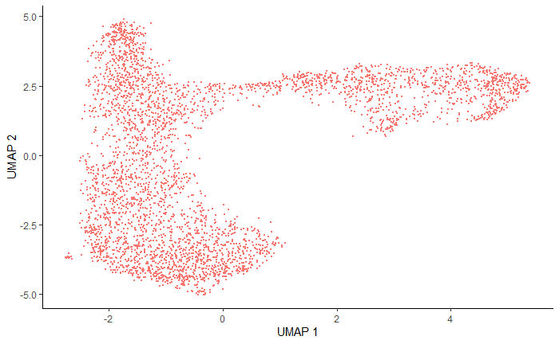

```r
plot_cells(cds_exp2, color_cells_by = 'sample') # note a single population - batch effect from before was real
```

# 2. FIND GENES TO USE IN MNN BATCH CORRECTION

Going to use genes expressed in over 500 cells across all 3 paclitaxel-treated samples in the two experiments

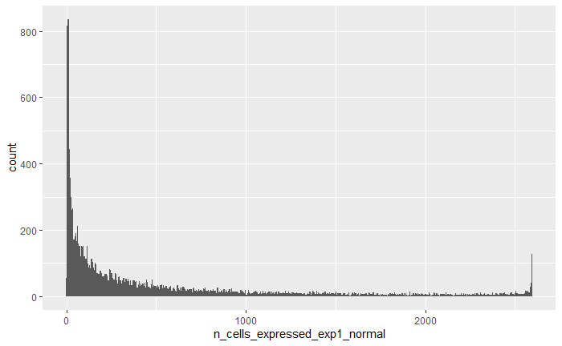

```r
# calculate the number of cells expressing each gene within each batch
n_cells_expressed_exp1_normal <- apply(exprs(cds_exp1[,which(colData(cds_exp1)$sample == 3)]), 1, function(x) sum(x > 0))
n_cells_expressed_exp1_lobulated <- apply(exprs(cds_exp1[,which(colData(cds_exp1)$sample == 4)]), 1, function(x) sum(x > 0))
n_cells_expressed_exp2_mixed <- apply(exprs(cds_exp2), 1, function(x) sum(x > 0))
# pick genes that are expressed in > 500 cells in each batch
chosen = Reduce(intersect, list(names(n_cells_expressed_exp1_normal[which(n_cells_expressed_exp1_normal > 500)]),
                                names(n_cells_expressed_exp1_lobulated[which(n_cells_expressed_exp1_lobulated > 500)]),
                                names(n_cells_expressed_exp2_mixed[which(n_cells_expressed_exp2_mixed > 500)]))) # choose highly variable genes that are also detected in Experiment 1
ggplot(as.data.frame(n_cells_expressed_exp1_normal), aes(x = n_cells_expressed_exp1_normal)) + geom_histogram(bins = 500)
```

# 3. PERFORM MNN BATCH CORRECTION

```r
# batch correct sample 3 onto sample 2, then 4 onto each otherm
mnn_exp1.exp2_taxol <- batchelor::fastMNN(monocle3::normalize_expr_data(cds_exp2[chosen,which(colData(cds_exp2)$sample == 2)],
                                                                  norm_method = 'log', pseudo_count = 1),
                                          monocle3::normalize_expr_data(cds_exp1[chosen,which(colData(cds_exp1)$sample == 3)],
                                                                  norm_method = 'log', pseudo_count = 1),
                                          monocle3::normalize_expr_data(cds_exp1[chosen,which(colData(cds_exp1)$sample == 4)],
                                                                  norm_method = 'log', pseudo_count = 1),
                                          d=50,
                                          k=20)
```

```
tied distances detected in nearest-neighbor calculationtied distances detected in nearest-neighbor calculation
```

```
No trajectory to plot. Has learn_graph() been called yet?
```

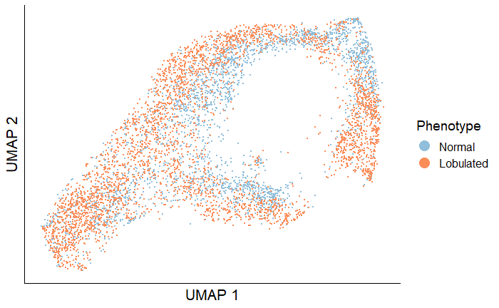

```r
# remake the cds for taxol but annotate with the new principle components
cds_exp1.mnn_taxol = cds_exp1[,which(colData(cds_exp1)$sample %in% c(3,4))] # remake taxol cds
cds_exp1.mnn_taxol = cds_exp1.mnn_taxol[, # reorder original cds to match mnn batch correction
                                        match(colnames(mnn_exp1.exp2_taxol)[which(mnn_exp1.exp2_taxol$batch %in% c(2,3))],
                                                                            colnames(cds_exp1.mnn_taxol))]
# replace PCA with mnn batch corrected PCA
reducedDim(cds_exp1.mnn_taxol, 'PCA') <- reducedDim(mnn_exp1.exp2_taxol)[which(mnn_exp1.exp2_taxol$batch %in% c(2,3)),]
# remake UMAP with batch correction PCs
cds_exp1.mnn_taxol = reduce_dimension(cds_exp1.mnn_taxol, reduction_method = 'UMAP', umap.n_neighbors = 30)
# add phenotype information
colData(cds_exp1.mnn_taxol)$pheno = factor('Normal', levels = c('Normal', 'Lobulated'))
colData(cds_exp1.mnn_taxol)[which(colData(cds_exp1.mnn_taxol)$sample == 4 ),'pheno'] = as.factor('Lobulated')
plot_cells(cds_exp1.mnn_taxol, color_cells_by = 'pheno', label_cell_groups = F) + scale_color_manual(values = c('#91bfdb', '#fc8d59')) +
  theme_classic() +
  theme(axis.text=element_text(size=14),
        axis.title=element_text(size=16),
        strip.text.x = element_text(size=16),
        strip.background = element_blank(),
        axis.text.y=element_blank(),
        axis.ticks.y=element_blank(),
        axis.text.x=element_blank(),
        axis.ticks.x=element_blank(),
        legend.title = element_text(size = 14),
        legend.text = element_text(size = 12)) +
  guides(color=guide_legend(title='Phenotype', override.aes = list(size=5)))
```

```r
# plot new UMAP
cds_exp1.mnn_taxol = reduce_dimension(cds_exp1.mnn_taxol, reduction_method = 'UMAP', umap.n_neighbors = 30)
plot_cells(cds_exp1.mnn_taxol, color_cells_by = 'Phase', label_cell_groups = F, cell_size = 0.1) +
  facet_wrap(~pheno, ncol = 2, scales = 'free_y') +
  #geom_density_2d(color = 'black', alpha = 0.5) +
  xlim(-6.75, 7.5) +
  ylim(-4, 4.5) +
  #geom_vline(xintercept = 0, linetype = 'dashed') +
  #geom_hline(yintercept = 0, linetype = 'dashed') +
  geom_text(aes(label = pheno),
                x = -Inf,
                y = Inf,
                size = 5,
                hjust = -0.1,
                vjust = 1,
            data = data.frame(pheno = c('Normal', 'Lobulated'),
                             val = c(1,2))) +
  theme_classic() +
  theme(axis.text=element_text(size=12),
        axis.title=element_text(size=14),
        strip.text.x = element_blank(),
        strip.background = element_blank(),
        axis.text.y=element_blank(),
        axis.ticks.y=element_blank(),
        axis.text.x=element_blank(),
        axis.ticks.x=element_blank(),
        panel.grid.major = element_line(size = 0.5,
                                        linetype = 'solid',
                                        colour = "grey"),
        panel.grid.minor = element_line(size = 0,
                                        linetype = 'solid',
                                        colour = "white"),
        legend.title = element_text(size = 12),
        legend.text = element_text(size = 12),
        legend.position ='bottom',
        plot.margin=unit(c(0.1,0.1,-0.1,0.1),"in")) +
  guides(color=guide_legend(title='Cell Cycle Phase', override.aes = list(size=5)))
```

```
No trajectory to plot. Has learn_graph() been called yet?
```

[figure not shown]

```r
ggsave('F4D.png', dpi = 900, width = 4.5, height = 2.75)
```

# 4. EXAMINE MNN BATCH CORRECTION OUTPUT FOR PCs THAT SEPARATE CELLS BY VCS LOBULATION BIN

Look at first 6 PCs

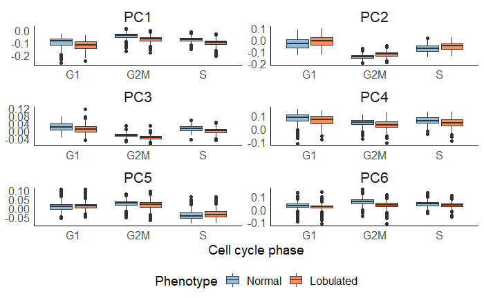

```r
# add principle components to colData
pca_rep1.mnn            <- base::cbind(data.frame(colData(cds_exp1.mnn_taxol)), data.frame(cds_exp1.mnn_taxol@reducedDims$PCA))
colnames(pca_rep1.mnn)  <- c('cell','S.Score','G2M.Score','Phase','sample','Size_Factor', 'pheno',
                             sapply(seq(1,50), function(x) paste0('PC', x)))
pca_rep1.mnn$experiment = 'Experiment 1 - VCS'
cols <- c('experiment', 'Phase', 'pheno', 'PC1', 'PC2', 'PC3', 'PC4', 'PC5', 'PC6')
to_plot = pca_rep1.mnn[,c(cols)]
to_plot = melt(to_plot, id.vars = cols[1:3])
# plot first 6 principle components. Demonstrates PCs 1-4 best distinguish between normal and low shape factor cells
ggplot(to_plot, aes(x = Phase, y = value, fill = pheno)) +
    geom_boxplot() +
    guides(color = FALSE) +
  theme_classic() +
    theme(axis.text=element_text(size=12),
          axis.title=element_text(size=14),
          strip.text.x = element_text(size = 16),
          strip.background = element_blank(),
          axis.ticks.y=element_blank(),
          axis.ticks.x=element_blank(),
          axis.title.y = element_blank(),
          legend.title = element_text(size = 14),
          legend.text = element_text(size = 12),
          legend.position="bottom") +
    xlab('Cell cycle phase') +
  facet_wrap(~variable, scales = 'free', ncol = 2) +
  scale_fill_manual(name = 'Phenotype', values = c('#91bfdb', '#fc8d59'))
ggsave('SF4C.png', width = 3.75, height = 5, dpi = 900)
```

# 5. GENERATE COMPOSITE LOBULATION SCORE USING THE PRINCIPLE COMPONENTS

### Check classification accuracy for PC1 vs. a composite score generated with a logistic regression that uses PCs 1-4 as predictor variables

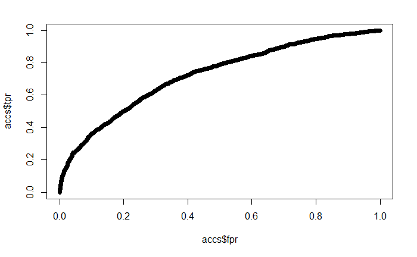

```r
library(AUC)
# use PC1 alone
accs <- roc(predictions = pca_rep1.mnn$PC1,
                 labels = as.factor(pca_rep1.mnn$sample == 3))
plot(x = accs$fpr, y = accs$tpr) # it's ok.
```

```r
print(auc(accs))
```

```
[1] 0.7236157
```

```r
# use first 4 PCs
nuclear_shape_score = glm(formula = as.factor(sample) ~ PC1 + PC2 + PC3 + PC4,
                      data = data.frame(pca_rep1.mnn),
                      family = 'binomial'(link = 'logit'))
accs <- roc(predictions = nuclear_shape_score$fitted.values,
                 labels = as.factor(pca_rep1.mnn$sample == 4))
print(auc(accs))
```

```
[1] 0.9052578
```

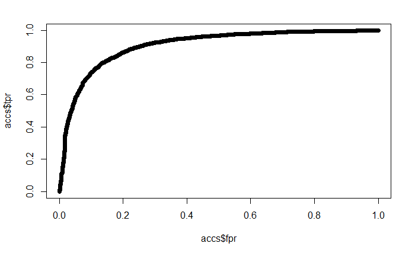

```r
plot(x = accs$fpr, y = accs$tpr) # pretty good! Let's try using this instead.
```

## check that the lobulation score does a good job of separating lobulated and normal-appearing cells

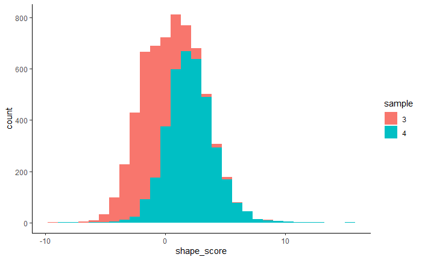

```r
if(all(names(nuclear_shape_score$fitted.values) == colnames(cds_exp1.mnn_taxol))) { # ensure names are in the same order
  colData(cds_exp1.mnn_taxol)$shape_score = nuclear_shape_score$linear.predictors} # use linear.predictor variable so that you don't get weird regression results
# add the score to the dataframe
ggplot(data.frame(colData(cds_exp1.mnn_taxol)), aes(x = shape_score, fill = sample)) + geom_histogram() + theme_classic()
```

## visualize UMAP with the lobulation_score

```
No trajectory to plot. Has learn_graph() been called yet?
Cells aren't colored in a way that allows them to be grouped.
```

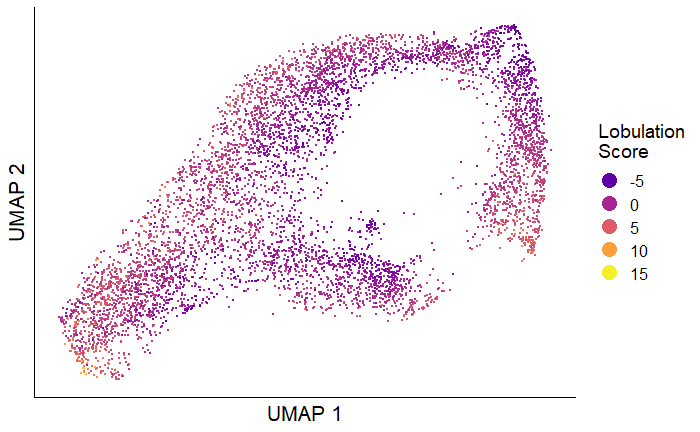

```r
plot_cells(cds_exp1.mnn_taxol, color_cells_by = 'shape_score') +
   theme_classic() +
  theme(axis.text=element_text(size=14),
        axis.title=element_text(size=16),
        strip.text.x = element_text(size=16),
        strip.background = element_blank(),
        axis.text.y=element_blank(),
        axis.ticks.y=element_blank(),
        axis.text.x=element_blank(),
        axis.ticks.x=element_blank(),
        legend.title = element_text(size = 14),
        legend.text = element_text(size = 12)) +
  guides(color=guide_legend(title='Lobulation\nScore', override.aes = list(size = 5)))
```

## Apply the lobulation score to the unseparated paclitaxel-treated replicate

```
No trajectory to plot. Has learn_graph() been called yet?
Cells aren't colored in a way that allows them to be grouped.
No trajectory to plot. Has learn_graph() been called yet?
```

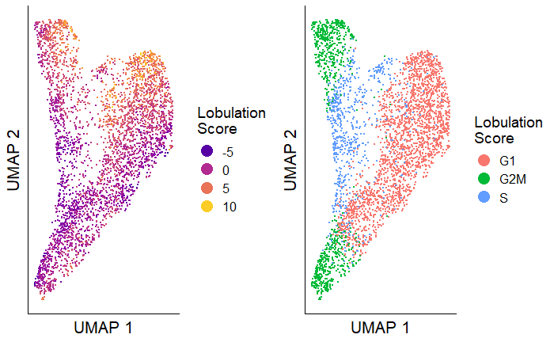

```r
# remake the cds for taxol, replicate 2 but use the new principle components
cds_exp2.mnn_taxol = cds_exp2[,which(colData(cds_exp2)$sample == 2)]
# reorder cds to match mnn batch correction
cds_exp2.mnn_taxol = cds_exp2.mnn_taxol[,match(colnames(mnn_exp1.exp2_taxol)[which(mnn_exp1.exp2_taxol$batch == 1)],
                                               colnames(cds_exp2.mnn_taxol))]
# replace PCA with mnn batch corrected PCA
reducedDim(cds_exp2.mnn_taxol, 'PCA') <- reducedDim(mnn_exp1.exp2_taxol)[which(mnn_exp1.exp2_taxol$batch == 1),]
# remake UMAP
cds_exp2.mnn_taxol = reduce_dimension(cds_exp2.mnn_taxol, reduction_method = 'UMAP', umap.n_neighbors = 30)
# apply the model to this sample
pca_rep2.mnn            <- base::cbind(data.frame(colData(cds_exp2.mnn_taxol)), data.frame(cds_exp2.mnn_taxol@reducedDims$PCA))
colnames(pca_rep2.mnn)  <- c('cell','S.Score','G2M.Score','Phase','sample','Size_Factor', 'pheno',
                             sapply(seq(1,50), function(x) paste0('PC', x)))
pca_rep2.mnn$shape_score <- predict(nuclear_shape_score, pca_rep2.mnn)
# annotate the colData with shape_score
colData(cds_exp2.mnn_taxol) = cbind(colData(cds_exp2.mnn_taxol), pca_rep2.mnn[,'shape_score'])
colnames(colData(cds_exp2.mnn_taxol)) = c('cell', 'S.Score', 'G2M.Score', 'Phase', 'sample', 'Size_Factor', 'pheno', 'shape_score')
ggarrange(plotlist = list(
  plot_cells(cds_exp2.mnn_taxol, color_cells_by = 'shape_score') +
   theme_classic() +
  theme(axis.text=element_text(size=14),
        axis.title=element_text(size=16),
        strip.text.x = element_text(size=16),
        strip.background = element_blank(),
        axis.text.y=element_blank(),
        axis.ticks.y=element_blank(),
        axis.text.x=element_blank(),
        axis.ticks.x=element_blank(),
        legend.title = element_text(size = 14),
        legend.text = element_text(size = 12)) +
  guides(color=guide_legend(title='Lobulation\nScore', override.aes = list(size = 5))),

  plot_cells(cds_exp2.mnn_taxol, color_cells_by = 'Phase') +
   theme_classic() +
  theme(axis.text=element_text(size=14),
        axis.title=element_text(size=16),
        strip.text.x = element_text(size=16),
        strip.background = element_blank(),
        axis.text.y=element_blank(),
        axis.ticks.y=element_blank(),
        axis.text.x=element_blank(),
        axis.ticks.x=element_blank(),
        legend.title = element_text(size = 14),
        legend.text = element_text(size = 12)) +
  guides(color=guide_legend(title='Lobulation\nScore', override.aes = list(size = 5)))
))
```

## Compare Lobulation scores across each replicate

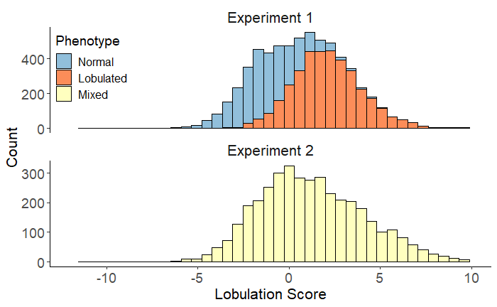

```r
# include data from replicate 1 as a comparison
merged_scores <- rbind(pca_rep2.mnn[,c('cell', 'shape_score', 'pheno')], data.frame(colData(cds_exp1.mnn_taxol))[,c('cell','shape_score', 'pheno')])
merged_scores$Exp = c(rep('Experiment 2', nrow(pca_rep2.mnn)), rep('Experiment 1', nrow(colData(cds_exp1.mnn_taxol))))
ggplot(merged_scores) +
  geom_histogram(aes(x = shape_score, fill = pheno),
                 bins = 40, color = 'black', size = 0.5) +
  facet_wrap(~Exp, ncol = 1, scales = 'free_y') + xlim(-7.5, 10) +
  theme_classic() +
  theme(axis.text=element_text(size=14),
        axis.title=element_text(size=16),
        strip.text.x = element_text(size=16),
        strip.background = element_blank(),
        legend.title = element_text(size = 14),
        legend.text = element_text(size = 12),
        legend.position = c(0, 1),
        legend.justification = c(-0.005, 1)) +
  xlim(-12, 10) +
  guides(fill=guide_legend(title='Phenotype')) +
  scale_fill_manual(values = c('#91bfdb', '#fc8d59', '#ffffbf')) +
  xlab('Lobulation Score') +
  ylab('Count')
ggsave('SF4D.png', dpi = 900, width = 4.5, height = 5)
```

# 6. USING THE ORIGINAL DATA FROM EXPERIMENT 2, PERFORM A DEG TEST ON THE LOBULATION SCORE, INCLUDING CELL CYCLE AS A COVARIATE

We include cell cycle as we know that it also varies with the principle components used to make the lobulation score (see PC plots above); and because cell cycle explains a lot of the gene expression variance

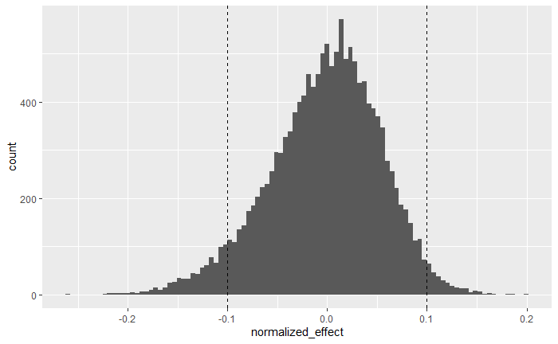

```r
degs_taxol_shape_exp2 <- fit_models(cds_exp2.mnn_taxol,
                               model_formula_str = '~shape_score + S.Score + G2M.Score')
# derive beta coefficients
coeffs_taxol_shape_exp2 <- coefficient_table(degs_taxol_shape_exp2)
coeffs_taxol_shape_exp2 <- as.data.frame(coeffs_taxol_shape_exp2)
#write.csv(coeffs_taxol_shape_exp2, 'degs_taxol_shape_exp2.csv')
# plot volcano plot
ggplot(coeffs_taxol_shape_exp2[which(coeffs_taxol_shape_exp2$term == 'shape_score'),], aes(x = normalized_effect)) + geom_histogram(bins = 100) + geom_vline(xintercept = -0.1, linetype='dashed') + geom_vline(xintercept = 0.1, linetype ='dashed')
```

```r
coeffs_taxol_shape_exp2$significant_deg = abs(coeffs_taxol_shape_exp2$normalized_effect) > 0.1 & coeffs_taxol_shape_exp2$q_value < 0.01
coeffs_taxol_shape_exp2$hvg = coeffs_taxol_shape_exp2$id %in% chosen
print(sum(coeffs_taxol_shape_exp2$significant_deg & coeffs_taxol_shape_exp2$term == 'shape_score')) # number of genes significantly associated with lobulation score
```

```
[1] 765
```

```r
print(sum(coeffs_taxol_shape_exp2$significant_deg & coeffs_taxol_shape_exp2$term == 'shape_score' & coeffs_taxol_shape_exp2$normalized_effect < 0) / sum(coeffs_taxol_shape_exp2$significant_deg & coeffs_taxol_shape_exp2$term == 'shape_score')) # number of genes that have higher expression in normal cells
```

```
[1] 0.8431373
```

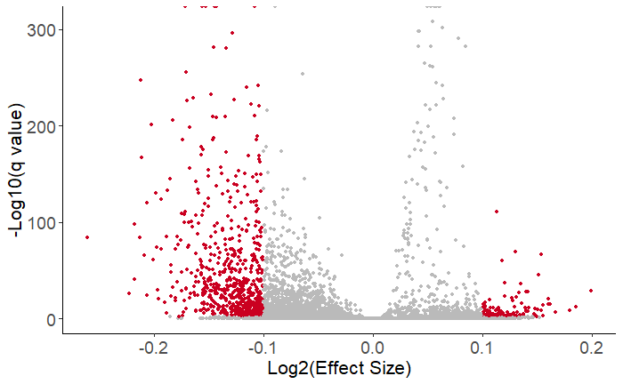

```r
write.csv(coeffs_taxol_shape_exp2[which(coeffs_taxol_shape_exp2$significant_deg & coeffs_taxol_shape_exp2$term == 'shape_score'),], 'ST5.csv')
ggplot(coeffs_taxol_shape_exp2[which(coeffs_taxol_shape_exp2$term == 'shape_score'),], aes(x = normalized_effect, y = -log10(q_value), color = significant_deg)) +
  geom_point(size = 1) +
  theme_classic() +
  theme(axis.text=element_text(size=14),
        axis.title=element_text(size=16),
        strip.text.x = element_text(size=16),
        strip.background = element_blank(),
        legend.title = element_text(size = 14),
        legend.text = element_text(size = 12)) +
  xlab('Log2(Effect Size)') +
  ylab('-Log10(q value)') +
  scale_color_manual(values = c('#bababa', '#ca0020')) +
  guides(color=FALSE)
ggsave('SF4E.png', width = 2.75, height = 2.5, dpi = 900)
```